# “Reproducible Research: Activity Monitoring”

#### **Author: Araceli Cruz**

```r
setwd("~/Desktop/COURSERA/MODULO5")
library(dplyr)
```

```r
library(ggplot2)
```

## **1.Loading and preprocessing the data**

#### **1.1 Reading the data**

```r
base<-read.csv("activity.csv",header=T,sep=",")
```

#### **1.2 Process/transform the data (if necessary) into a format suitable for your analysis**

```r
str(base)
```

```
## 'data.frame':    17568 obs. of  3 variables:
##  $ steps   : int  NA NA NA NA NA NA NA NA NA NA ...
##  $ date    : Factor w/ 61 levels "2012-10-01","2012-10-02",..: 1 1 1 1 1 1 1 1 1 1 ...
##  $ interval: int  0 5 10 15 20 25 30 35 40 45 ...
```

Dates are stored as factors, so I use as.Date function

```r
base$date<-as.Date(base$date,"%Y-%m-%d")
```

## **2.What is mean total number of steps taken per day?**

#### **2.1 Calculate the total number of steps taken per day**

I use complete.cases function and I get total steps per day using dplyr package

```r
temp<-base[complete.cases(base),]
steps_per_day<-temp%>%group_by(date)%>%
        summarise(total_steps=sum(steps))
steps_per_day
```

```
## Source: local data frame [53 x 2]
##
##          date total_steps
##        (date)       (int)
## 1  2012-10-02         126
## 2  2012-10-03       11352
## 3  2012-10-04       12116
## 4  2012-10-05       13294
## 5  2012-10-06       15420
## 6  2012-10-07       11015
## 7  2012-10-09       12811
## 8  2012-10-10        9900
## 9  2012-10-11       10304
## 10 2012-10-12       17382
## ..        ...         ...
```

#### **2.2 Make a histogram of the total number of steps taken each day**

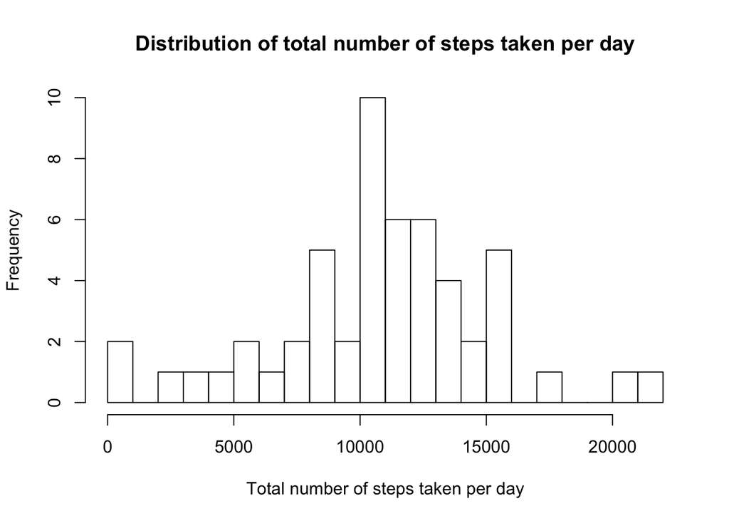

```r
hist(steps_per_day$total_steps,
     main="Distribution of total number of steps taken per day",
     xlab="Total number of steps taken per day",
     ylab="Frequency",breaks=20)
```

#### **2.3 Calculate and report the mean and median of the total number of steps taken per day**

```r
mean_steps<-steps_per_day%>%
        summarise(mean_steps=mean(total_steps))
mean_steps
```

```
## Source: local data frame [1 x 1]
##
##   mean_steps
##        (dbl)
## 1   10766.19
```

```r
median_steps<-steps_per_day%>%
        summarise(median_steps=median(total_steps))
median_steps
```

```
## Source: local data frame [1 x 1]
##
##   median_steps
##          (int)
## 1        10765
```

## **3.What is the average daily activity pattern?**

#### **3.1 Make a time series plot (i.e. type = “l”) of the 5-minute interval (x-axis) and the average number of steps taken, averaged across all days (y-axis)**

I am still ignoring missing values and I get the mean of steps across all days

```r
temp<-base[complete.cases(base),]
avrg_interval<-temp%>%group_by(interval)%>%summarise(avrg=mean(steps))
```

I get the plot

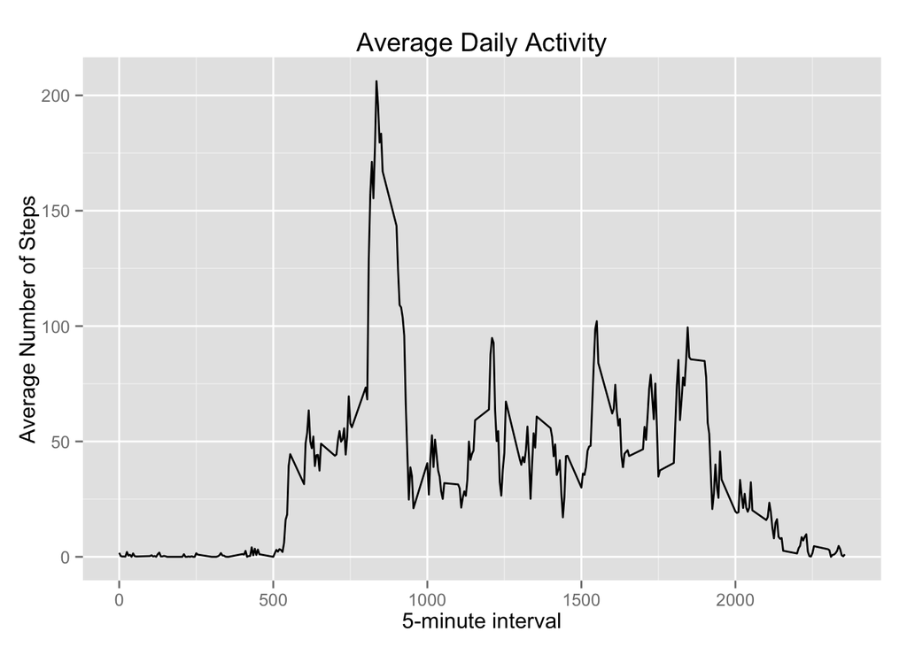

```r
ggplot(data=avrg_interval, aes(x=interval, y=avrg)) +
        geom_line()+
        ggtitle("Average Daily Activity")+
        xlab("5-minute interval")+
        ylab("Average Number of Steps")
```

#### **3.2 Which 5-minute interval, on average across all the days in the dataset, contains the maximum number of steps?**

First I get the maximum value using max function, after that I get the interval which contains the maximum value

```r
maximo<-max(avrg_interval$avrg)
maximo
```

```
## [1] 206.1698
```

```r
avrg_interval[avrg_interval$avrg==maximo,]
```

```
## Source: local data frame [1 x 2]
##
##   interval     avrg
##      (int)    (dbl)
## 1      835 206.1698
```

## **4.Imputing missing values**

#### **4.1 Calculate and report the total number of missing values in the dataset (i.e. the total number of rows with NAs)**

```r
sum(!complete.cases(base))
```

```
## [1] 2304
```

#### **4.2 Devise a strategy for filling in all of the missing values in the dataset.**

I am going to use the mean. First, I get the data with just incomplete cases. Then, I join the resulting table with the average number of steps by interval and use it to fill missing data.

```r
missingvalues<-base[!complete.cases(base),]

missingvalues<-missingvalues%>%inner_join(avrg_interval,by="interval")%>%
        mutate(steps=avrg)%>%select(-avrg)
```

#### **4.3 Create a new dataset that is equal to the original dataset but with the missing data filled in.**

```r
completeData<-base
completeData[which(is.na(completeData$steps)), 1] <- missingvalues[ , 1]
sum(!complete.cases(completeData))
```

```
## [1] 0
```

#### **4.4 Make a histogram of the total number of steps taken each day and calculate and report the mean and median total number of steps taken per day.**

```r
steps_per_day2<-completeData%>%group_by(date)%>%
        summarise(total_steps=sum(steps))
```

I get the histogram with complete data

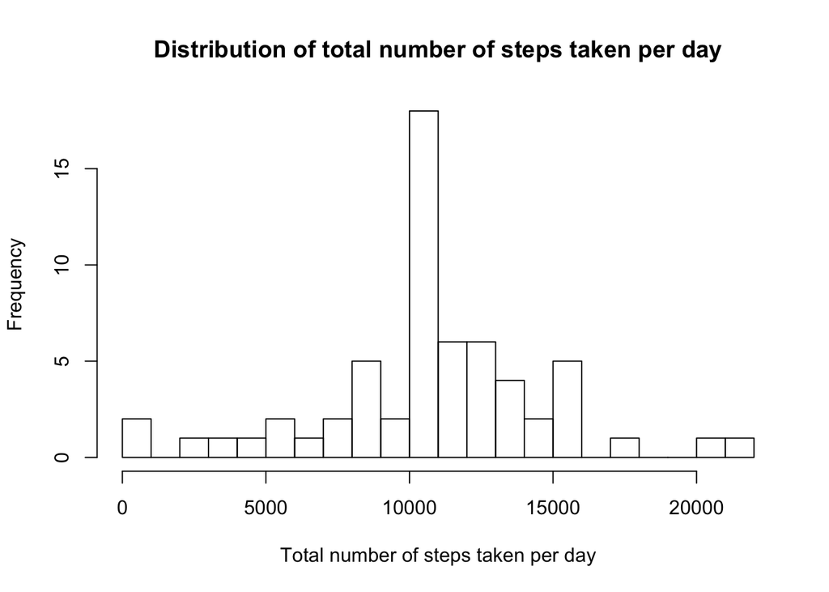

```r
hist(steps_per_day2$total_steps,
     main="Distribution of total number of steps taken per day",
     xlab="Total number of steps taken per day",
     ylab="Frequency",breaks=20)
```

I get the mean and mean. The mean doesn’t change, however the median does.

```r
mean_steps2<-steps_per_day2%>%
        summarise(mean_steps=mean(total_steps))
mean_steps2
```

```
## Source: local data frame [1 x 1]
##
##   mean_steps
##        (dbl)
## 1   10766.19
```

```r
median_steps2<-steps_per_day2%>%
        summarise(median_steps=median(total_steps))
median_steps2
```

```
## Source: local data frame [1 x 1]
##
##   median_steps
##          (dbl)
## 1     10766.19
```

## **5.Are there differences in activity patterns between weekdays and weekends?**

#### **5.1 Create a new factor variable in the dataset with two levels: “weekday” and “weekend” indicating whether a given date is a weekday or weekend day.**

```r
completeData<- completeData%>%
        mutate(weekdays=ifelse(weekdays(date) == "Saturday" |
                                       weekdays(date) == "Sunday",
                               "weekend",
                               "weekday"))
completeData$weekdays <- as.factor(completeData$weekdays)
```

#### **5.2 Make a panel plot containing a time series plot (i.e. type = “l”) of the 5-minute interval (x-axis) and the average number of steps taken, averaged across all weekday days or weekend days (y-axis).**

I get a new mean of steps but grouping by interval and weekdays variables

```r
avrg_interval2<-completeData%>%group_by(interval,weekdays)%>%
        summarise(avrg=mean(steps))
```

I get the plot

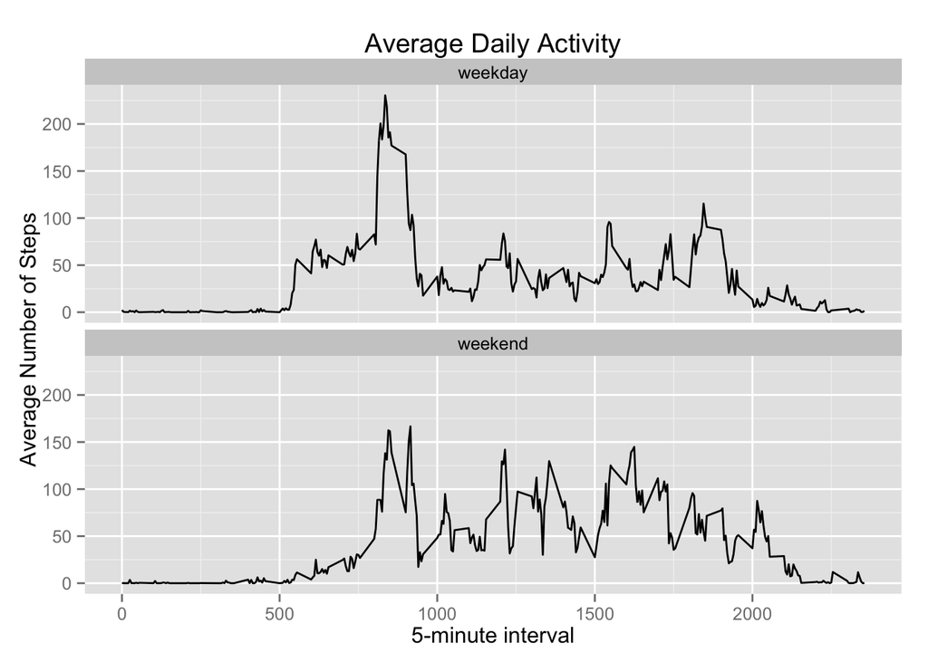

```r
ggplot(data=avrg_interval2, aes(x=interval, y=avrg)) +
        geom_line()+
        facet_wrap(~ weekdays, ncol=1) +
        ggtitle("Average Daily Activity")+
        xlab("5-minute interval")+
        ylab("Average Number of Steps")
```